# Analyse de la modélisation des sinistres graves

Kezhan SHI

31 mai 2014

# 1 Introduction

Les sinistres graves sont en général modélisés avec le modèle fréquence-coût. Quand le modèle est finalisé, l’analyse est importante afin de bien comprendre les résultats de modélisation et par conséquent trouver des incohérences éventuelles de modèle.

# 2 Paramètres de modèle

## 2.1 Modèle de coût

On peut prendre la loi de Pareto

```r
library(VGAM)
# install.packages("DT")
library(DT)
library(ggplot2)

seuil=2e6
alpha=2.5
```

## 2.2 Modèle de Fréquence

On peut prendre la loi de Poisson ou la binomiale négative

- pour la loi de Poisson, on a besoin uniquement d’un paramètre qui caractérise la moyenne et la variance.

```r
f=10
```

- en pratique, on peut voir que la variance n’est pas forcément également à la moyenne, on peut adopter la loi binomiale négative

```r
mf=10
vf=16
# nb=rnbinom(1,size=mf^2/(vf-mf),mu=mf)
```

# 3 Nombres de sinistres par tranche

## 3.1 Programme de simulation

On peut simuler les sinistres par tranche de 1M, de 2M à 20M. Pour chaque tranche, il est possible de calculer les valeurs suivantes :

```r
output
```

```
##       From      To Mean_frequency Mean_cost Sd_frequency  Sd_cost
## 1  2.0e+06 3.0e+06          6.298  380808.0   2.46602459 119711.7
## 2  3.0e+06 4.0e+06          1.833  419797.6   1.36564123 223772.7
## 3  4.0e+06 5.0e+06          0.748  445868.3   0.87935730 257376.2
## 4  5.0e+06 6.0e+06          0.350  475226.6   0.59821222 274296.5
## 5  6.0e+06 7.0e+06          0.194  479213.3   0.42959114 274184.6
## 6  7.0e+06 8.0e+06          0.130  429465.0   0.35668926 290192.1
## 7  8.0e+06 9.0e+06          0.071  474469.5   0.26081991 296032.6
## 8  9.0e+06 1.0e+07          0.044  394637.6   0.21001930 261091.7
## 9  1.0e+07 1.1e+07          0.027  467604.0   0.16216441 265912.6
## 10 1.1e+07 1.2e+07          0.021  402224.9   0.15027169 277139.6
## 11 1.2e+07 1.3e+07          0.032  552700.8   0.17608807 274117.9
## 12 1.3e+07 1.4e+07          0.015  493371.0   0.12161328 246821.3
## 13 1.4e+07 1.5e+07          0.016  621696.6   0.12553788 220833.1
## 14 1.5e+07 1.6e+07          0.012  399223.2   0.10893974 320587.0
## 15 1.6e+07 1.7e+07          0.006  379443.0   0.07726558 294614.7
## 16 1.7e+07 1.8e+07          0.006  616661.8   0.07726558 277321.9
## 17 1.8e+07 1.9e+07          0.005  623383.9   0.07056897 279233.9
## 18 1.9e+07 2.0e+07          0.006  503434.7   0.07726558 301783.8
```

## 3.2 Visualisation des courbes

On peut visualiser le nombre de sinistres par tranche.

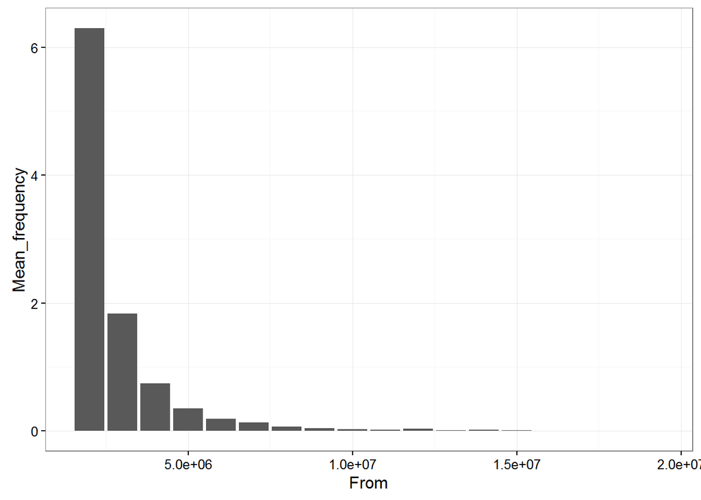

```r
output=as.data.frame(output)
# error bar with sd
ggplot(data=output, aes(x=From,y=`Mean_frequency`)) +
  geom_bar(position=position_dodge(), stat="identity") +
  theme_bw()
```

On peut construire une barre d’erreur à l’aide l’écart-type pour visualiser la volatilité des nombres. On voit que la moyenne moins la volatilité est parfois négative. Ainsi pour avoir un graphique cohérent, on peut regarder plutôt un quantile donné.

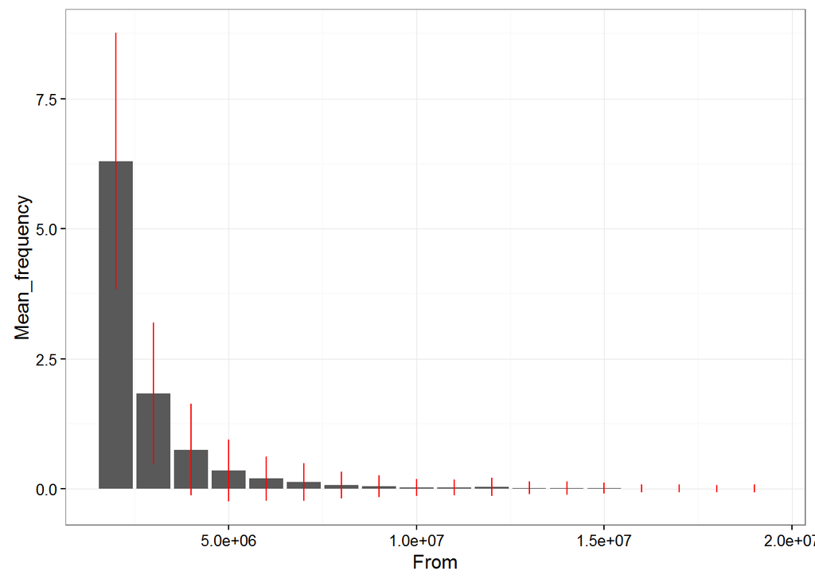

```r
output=as.data.frame(output)
# error bar with sd
ggplot(data=output, aes(x=From,y=`Mean_frequency`)) +
  geom_bar(position=position_dodge(), stat="identity") +
  geom_errorbar(aes(ymin=`Mean_frequency`-Sd_frequency, ymax=`Mean_frequency`+Sd_frequency),width=0.2,
                position=position_dodge(.1),col=2)+
  theme_bw()
```

# 4 Analyse de la probabilité de survenance des sinistres

L’OEP ou Occurence Exceedance Probability caratérise la probabilité de survenance des gros montants. On peut faire des simulations pour obtenir la courbe. Il y a également une formule fermée.

L’AEP ou Aggregate Exceedance Probability caratérise la probabilité des sommes annuelles de sinistres.

## 4.1 Simulation OEP

```r
sinmax=rep(0,nbsim)
for (k in (1:nbsim)) {
  sin0 = rpareto(rpois(1,f),seuil,alpha)
  sinmax[k]=max(sin0)
}

probs=seq(0,1,0.01)
q=quantile(probs=probs,sinmax)
pr=1/(1-probs) # Période de retour
```

## 4.2 Formule fermée OEP

```r
FX=1+(log(probs)/f)

q2=qpareto(p=FX,seuil,alpha)
data.frame(probs=probs,pretour=pr,simul=q,form=q2)
```

```
##      probs    pretour    simul     form
## 0%    0.00   1.000000  2395317      NaN
## 1%    0.01   1.010101  2807141  2727293
## 2%    0.02   1.020408  2929852  2911183
## 3%    0.03   1.030928  3084843  3041428
## 4%    0.04   1.041667  3165206  3147374
## 5%    0.05   1.052632  3209088  3239133
## 6%    0.06   1.063830  3340364  3321519
## 7%    0.07   1.075269  3396595  3397236
## 8%    0.08   1.086957  3451206  3467970
## 9%    0.09   1.098901  3531214  3534853
## 10%   0.10   1.111111  3580471  3598684
## 11%   0.11   1.123596  3631410  3660053
## 12%   0.12   1.136364  3661242  3719410
## 13%   0.13   1.149425  3714055  3777106
## 14%   0.14   1.162791  3808803  3833422
## 15%   0.15   1.176471  3867980  3888589
## 16%   0.16   1.190476  3918345  3942799
## 17%   0.17   1.204819  3959620  3996214
## 18%   0.18   1.219512  4001336  4048972
## 19%   0.19   1.234568  4067873  4101193
## 20%   0.20   1.250000  4126397  4152984
## 21%   0.21   1.265823  4171121  4204439
## 22%   0.22   1.282051  4204936  4255641
## 23%   0.23   1.298701  4267863  4306668
## 24%   0.24   1.315789  4291452  4357589
## 25%   0.25   1.333333  4342279  4408469
## 26%   0.26   1.351351  4396110  4459370
## 27%   0.27   1.369863  4445627  4510347
## 28%   0.28   1.388889  4492830  4561454
## 29%   0.29   1.408451  4557139  4612744
## 30%   0.30   1.428571  4622816  4664266
## 31%   0.31   1.449275  4673915  4716068
## 32%   0.32   1.470588  4716607  4768198
## 33%   0.33   1.492537  4781449  4820701
## 34%   0.34   1.515152  4835488  4873624
## 35%   0.35   1.538462  4894415  4927013
## 36%   0.36   1.562500  4924945  4980913
## 37%   0.37   1.587302  4953373  5035370
## 38%   0.38   1.612903  5012145  5090431
```

[output cut: 47 more lines]

```
## 86%   0.86   7.142857 10447373 10706391
## 87%   0.87   7.692308 10822549 11053425
## 88%   0.88   8.333333 11309057 11438585
## 89%   0.89   9.090909 11627014 11869959
## 90%   0.90  10.000000 11793072 12358303
## 91%   0.91  11.111111 12253304 12918308
## 92%   0.92  12.500000 13005286 13570689
## 93%   0.93  14.285714 14082061 14345824
## 94%   0.94  16.666667 15436627 15290538
## 95%   0.95  20.000000 16299326 16481842
## 96%   0.96  25.000000 17626901 18058111
## 97%   0.97  33.333333 19399760 20302174
## 98%   0.98  50.000000 22560709 23925783
## 99%   0.99 100.000000 26000515 31634266
## 100%  1.00        Inf 64117950      Inf
```

# 5 Utilisation

Cette analyse peut permettre une meilleure vision des sinistres graves. Elle peut être utile pour le provisionnement, le pricing, et la réassurance.